# 平行線作圖與平行角關係

> 來源整理：改國二下3_尺規作圖_易讀版.md

## 過線外一點作平行線

> 學習目標：過線外一點作平行線，可以複製角，也可以先作垂線再作垂線。

### 先抓住核心

- 已知直線 L 與線外點 A，要作通過 A 且平行 L 的直線。
- 方法一：先作一條截線，再把 L 與截線形成的角複製到 A 點。
- 方法二：先過 A 作一條垂直 L 的直線，再過 A 作這條垂線的垂線。
- 若兩直線同時垂直於同一條直線，這兩直線平行。
- 平行線作圖常和等角作圖、垂線作圖連在一起。

### 作圖流程

1. 複製角法：畫截線，找出與 L 的角。
2. 把這個角複製到 A 點，得到新直線 M。
3. 垂線法：過 A 作 AH 垂直 L。
4. 再過 A 作 M 垂直 AH，則 M 平行 L。

### 公式、性質與判斷

- **平行作圖**：同位角相等可推出平行。
- **垂線法**：同垂直於一線的兩直線互相平行。

### 例題拆解

- 若 M 與 L 都垂直 AH，則 M // L。
- 若複製角使同位角相等，也可判斷新直線與原直線平行。

### 易錯提醒

- 複製角時角放錯側，可能得到與 L 不平行的直線。
- 垂線法第二次沒有經過 A 點，答案就不是過 A 的平行線。

### 小練一下

- 過線外一點作平行線至少可以用哪兩種想法？
- 為什麼兩條線都垂直同一條線時會平行？

### 記憶鉤子

- 平行線作圖可以用『等角』，也可以用『雙垂直』。
- 會作垂線和等角後，平行線其實是組合技。

### 圖像化理解

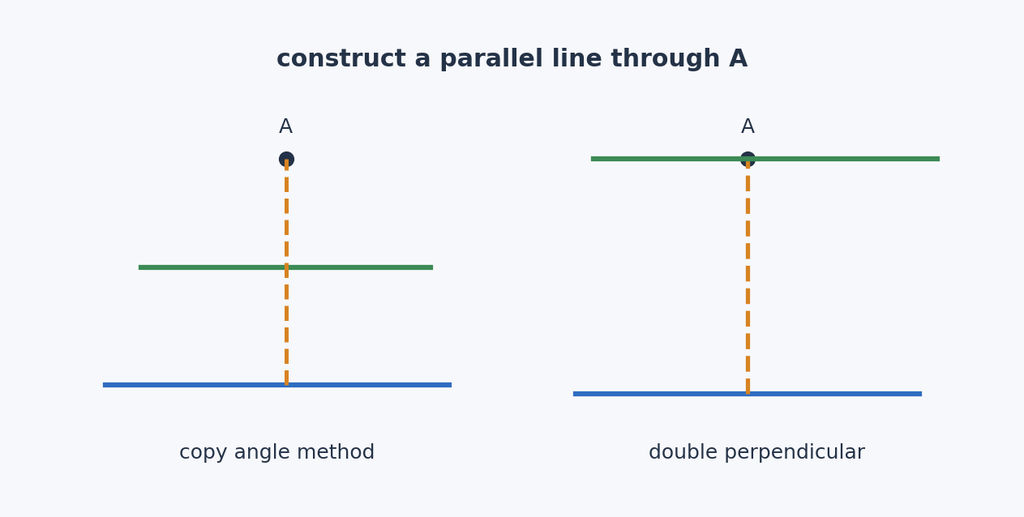

過線外一點作平行線

## 平行線、截線與三種截角

> 學習目標：兩條平行線被一條截線切開時，會出現同位角、內錯角、同側內角。

### 先抓住核心

- 在同一平面上，兩直線不相交且距離保持一致，可稱為平行。
- 一條直線切過兩條直線，這條線叫截線。
- 同位角在兩個交點的相同位置；平行時同位角相等。
- 內錯角在兩平行線內側且分居截線兩側；平行時內錯角相等。
- 同側內角在兩平行線內側且位於截線同側；平行時同側內角互補。

### 作圖流程

1. 先找兩條被截的線。
2. 再找穿過它們的截線。
3. 看角的位置：同位置、內側異側、內側同側。
4. 套性質：同位角等、內錯角等、同側內角和 180°。

### 公式、性質與判斷

- **同位角**：相等。
- **內錯角**：相等。
- **同側內角**：互補，和為 180°。

### 例題拆解

- 若 L1 // L2 且同位角之一是 55 度，另一個同位角也是 55 度。
- 若一個同側內角是 55 度，另一個同側內角是 125 度。

### 易錯提醒

- 把同側內角誤當成相等，忘記它們是互補。
- 沒有先確認兩線平行，就直接套平行線性質。

### 小練一下

- 同位角與內錯角在平行線下是相等還是互補？
- 同側內角的和是多少？

### 記憶鉤子

- 平行線角度題先命名角的位置，再套性質。
- 同側內角這個名字裡的『同側』是相對於截線。

### 圖像化理解

[figure not shown]

平行線、截線與三種截角

## 平行線性質與判別

> 學習目標：已知平行可推出角度關係；反過來，角度關係也可以判斷兩線平行。

### 先抓住核心

- 性質題：如果已知 L1 // L2，就可以使用同位角相等、內錯角相等、同側內角互補。
- 判別題：如果兩直線被截線所截且同位角相等，就可判斷兩直線平行。
- 如果內錯角相等，也可判斷兩直線平行。
- 如果同側內角互補，也可判斷兩直線平行。
- 解題時要分清楚你是『已知平行求角』，還是『已知角求平行』。

### 作圖流程

1. 先看題目是否已經給 L1 // L2。
2. 若已知平行，就用三種角度性質求未知角。
3. 若要證明平行，就找三種角度關係是否成立。
4. 最後寫清楚使用的是同位角、內錯角，還是同側內角。

### 公式、性質與判斷

- **性質**：平行 -> 角度關係。
- **判別**：角度關係 -> 平行。
- **三種判別**：同位角等、內錯角等、同側內角互補。

### 例題拆解

- 若 L1 // L2，角 1 = 55 度，且角 1 與角 2 是內錯角，則角 2 = 55 度。
- 若兩直線被截線切出一組同位角相等，則可判斷兩直線平行。
- 若一組同側內角是 100 度與 80 度，和為 180 度，也可判斷兩線平行。

### 易錯提醒

- 題目沒有給平行，卻直接用平行線性質。
- 明明要求證平行，卻只算角度沒有寫判別理由。

### 小練一下

- 同位角相等是性質還是判別？
- 若同側內角和為 180 度，可以推出什麼？

### 記憶鉤子

- 箭頭方向：平行推出角度，是性質；角度推出平行，是判別。
- 不要只寫答案角度，也要寫使用哪個性質。

### 圖像化理解

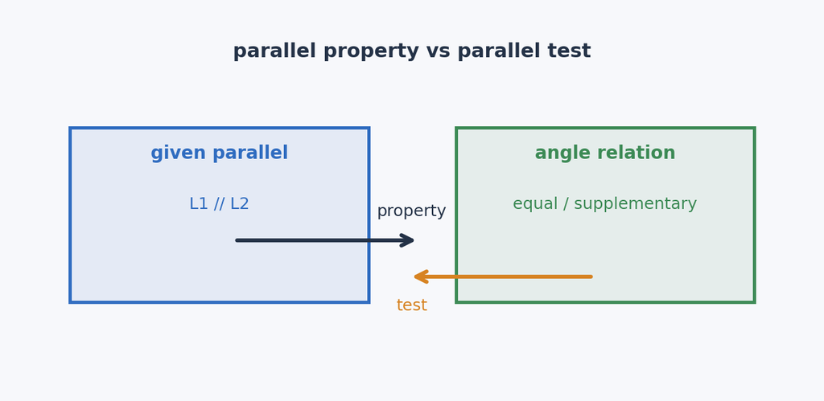

平行線性質與判別

圖解：用箭頭表示『平行推出角』與『角推出平行』兩種方向。

## 平行線角度追蹤與三角形定理

> 學習目標：複雜角度題可以透過作輔助平行線，把角一步一步搬到好算的位置。

### 先抓住核心

- 平行線角度追蹤常用『作過某點的輔助平行線』來拆角。
- Z 字形常對應內錯角相等，F 字形常對應同位角相等，U 字形常對應同側內角互補。
- 三角形內角和 180 度可用過頂點作底邊平行線來證明。
- 三角形外角等於兩個不相鄰內角和，也可用平行線性質證明。
- 遇到折線角度總和，可逐段作平行線，把角搬到同一條直線附近。

### 作圖流程

1. 先標出已知平行線。
2. 找出截線與折線上的角。
3. 必要時過轉折點作輔助平行線。
4. 用同位角、內錯角、同側內角逐步替換。
5. 最後用直線 180 度、周角 360 度或三角形內角和收尾。

### 公式、性質與判斷

- **三角形內角和**：A+B+C = 180°。
- **外角定理**：外角 = 兩個不相鄰內角和。
- **折線角**：常靠輔助平行線逐段搬角。

### 例題拆解

- 若平行線中一角是 55 度，與它互補的同側內角是 125 度。
- 若三角形兩角是 35 度與 45 度，第三角是 100 度；外角則可用 35+45=80 度。
- 若折線角題給出 40 度、70 度、25 度，常可用角度搬移得到 40+70-25 = 85 度。

### 易錯提醒

- 把同側內角互補誤用成相等。
- 作輔助線後沒有說明它與哪條線平行，導致推理斷掉。

### 小練一下

- 三角形外角等於哪兩個角的和？
- 遇到折線角度題，為什麼常要作輔助平行線？

### 記憶鉤子

- 平行線角度題像搬家具：先搭一條平行線，角就能移到能計算的位置。
- Z、F、U 三種圖像可以快速辨認角度關係。

### 圖像化理解

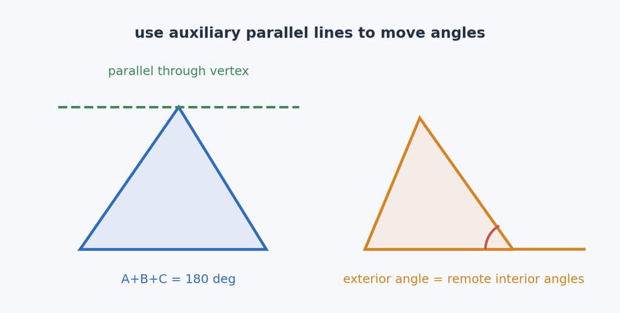

平行線角度追蹤與三角形定理

圖解：示意輔助平行線如何協助證明三角形內角和與外角定理。

## 平行線的面積、摺疊與反射應用

> 學習目標：平行線不只用來算角，也能保證高度相同，進而比較面積。

### 先抓住核心

- 兩條平行線之間的距離固定，所以夾在平行線間、同底的三角形面積相等。
- 三角形面積是底乘高除以 2；底相同、高相同，面積就相同。
- 摺疊題常保留等角或等長，搭配平行線性質可求角。
- 光線在垂直鏡面反射題中，常利用入射角等於反射角，再搭配同側內角互補判斷平行。
- 面積題要先找底和高，不要只看圖形外觀。

### 作圖流程

1. 面積題先找共用底邊。
2. 再看頂點是否在同一條與底邊平行的線上。
3. 若同底等高，三角形面積相等。
4. 摺疊或反射題先標出相等角，再用平行線角度關係轉換。

### 公式、性質與判斷

- **三角形面積**：Area = base*height/2。
- **同底等高**：面積相等。
- **反射**：入射角 = 反射角。

### 例題拆解

- 若兩個三角形共用底 BC，且兩個頂點都在與 BC 平行的同一直線上，面積相等。
- 若直線 L // M，折線中的角可用平行線性質一段一段轉換。
- 若兩面鏡互相垂直，反射角相等加上同側內角互補，可判斷入射光與反射光平行。

### 易錯提醒

- 只看圖形形狀不同就以為面積不同，忘記同底等高。
- 摺疊後忘記對應角相等，導致角度推理少一段。

### 小練一下

- 同底等高的兩個三角形面積一定相等嗎？
- 摺疊題中常保留哪些量？

### 記憶鉤子

- 面積比較先問：底一樣嗎？高一樣嗎？
- 摺疊與反射題其實都是『保留角或長度』再配合平行線。

### 圖像化理解

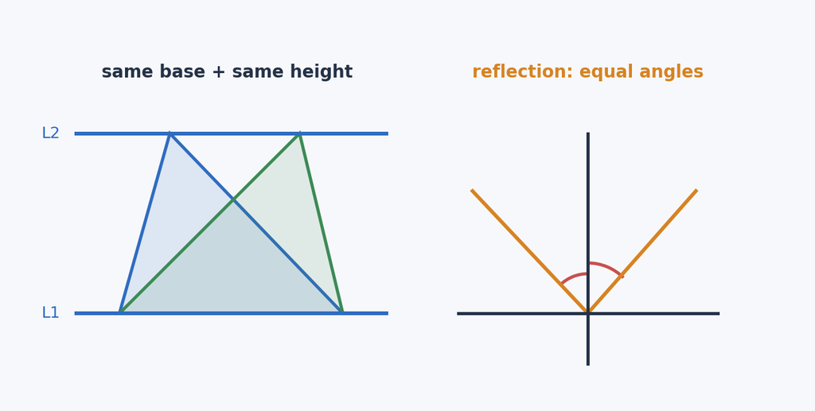

平行線的面積、摺疊與反射應用

圖解：用同底等高三角形與反射角示意平行線的應用。